Anna Reynolds

2019-04-26

## Overview

A few exciting Tennis-related datasets this week, all of which come courtesy of Wikipedia! https://github.com/rfordatascience/tidytuesday/tree/master/data/2019/2019-04-09

## Load data

```r
library(tidyverse)
library(ggrepel)
grand_slams <- readr::read_csv("https://raw.githubusercontent.com/rfordatascience/tidytuesday/master/data/2019/2019-04-09/grand_slams.csv")
```

```r
#https://github.com/bbc/bbplot
style <- function ()
{
    font <- "IBM Plex Sans"
    ggplot2::theme(plot.title = ggplot2::element_text(family = font,
        size = 28, face = "bold", color = "#222222"), plot.subtitle = ggplot2::element_text(family = font,
        size = 22, margin = ggplot2::margin(9, 0, 9, 0)), plot.caption = ggplot2::element_blank(),
        legend.position = "none", legend.text.align = 0, legend.background = ggplot2::element_blank(),
        legend.title = ggplot2::element_blank(), legend.key = ggplot2::element_blank(),
        legend.text = ggplot2::element_text(family = font, size = 18,
            color = "#222222"), axis.title = ggplot2::element_blank(),
        axis.text = ggplot2::element_text(family = font, size = 18,
            color = "#222222"), axis.text.x = ggplot2::element_text(margin = ggplot2::margin(5,
            b = 10)), axis.ticks = ggplot2::element_blank(),
        axis.line = ggplot2::element_blank(), panel.grid.minor = ggplot2::element_blank(),
        panel.grid.major.y = ggplot2::element_line(color = "#cbcbcb"),
        panel.grid.major.x = ggplot2::element_blank(), panel.background = ggplot2::element_blank(),
        strip.background = ggplot2::element_rect(fill = "white"),
        strip.text = ggplot2::element_text(size = 22, hjust = 0))
}
```

## Analysis/visualization

Lets look at the cumulative number of grand slam wins over time for men and women using a step chart. Inspired by John Murdoch-Burns https://gist.github.com/johnburnmurdoch/bd20db77b2582031604ccd1bdc4be582 Note: there are some duplicate records in the data set that need to be removed.

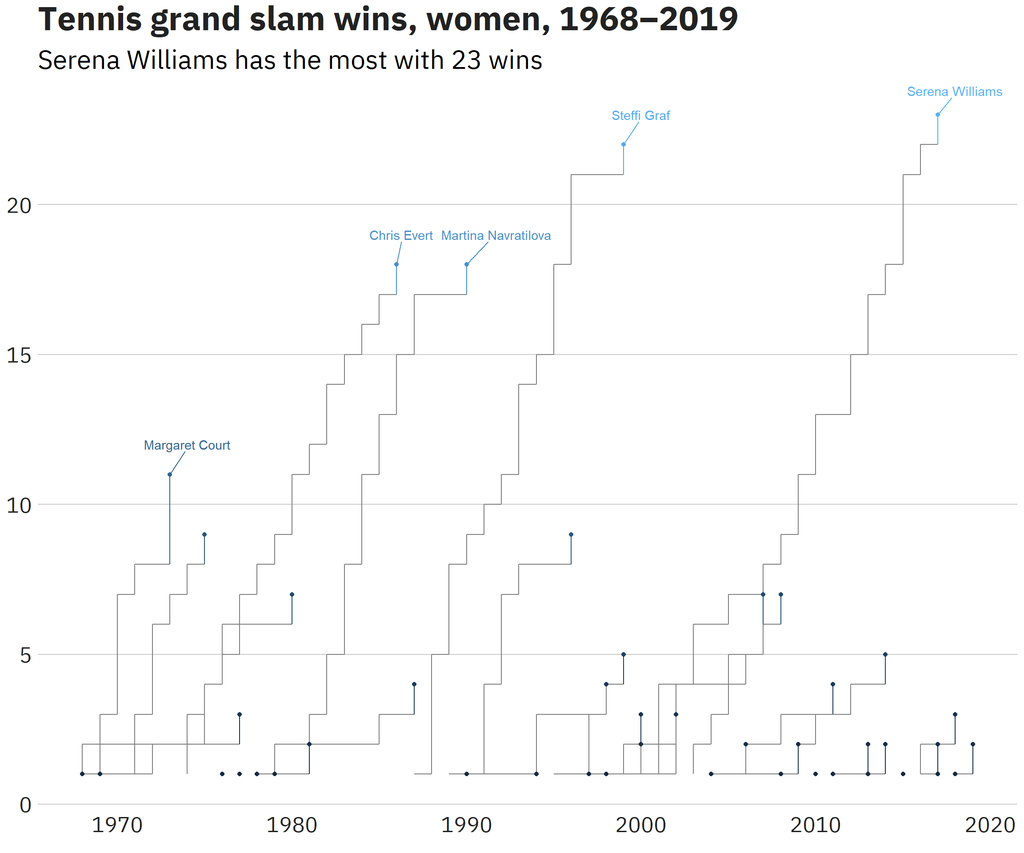

```r
women_gs <-
  grand_slams %>% filter(gender == "Female") %>% group_by(name) %>% distinct(year, tournament_date, .keep_all = TRUE) %>% mutate(rolling_win_count2 = row_number()) %>%  mutate(total_wins = if_else(year != max(year), NA_integer_, max(rolling_win_count2))) %>%  mutate(label = if_else(year == max(year), as.character(name), NA_character_))

  women <- ggplot(women_gs,
  aes(year, rolling_win_count2, label = name, colour = total_wins)) +
  geom_step(data = women_gs,
  mapping = aes(x = year, y = rolling_win_count2, group = name)) +
  geom_text_repel(
  aes(label = label),
  data          = subset(women_gs, rolling_win_count2 > 10),
  nudge_x = 1, nudge_y = 1,
  na.rm = TRUE
  ) + labs(
  x = "Year",
  y = "Number of wins",
  title = "Tennis grand slam wins, women, 1968\u20132019",
  subtitle = "Serena Williams has the most with 23 wins"
  ) + style() + geom_point(aes(x=year, y=total_wins))
women
```

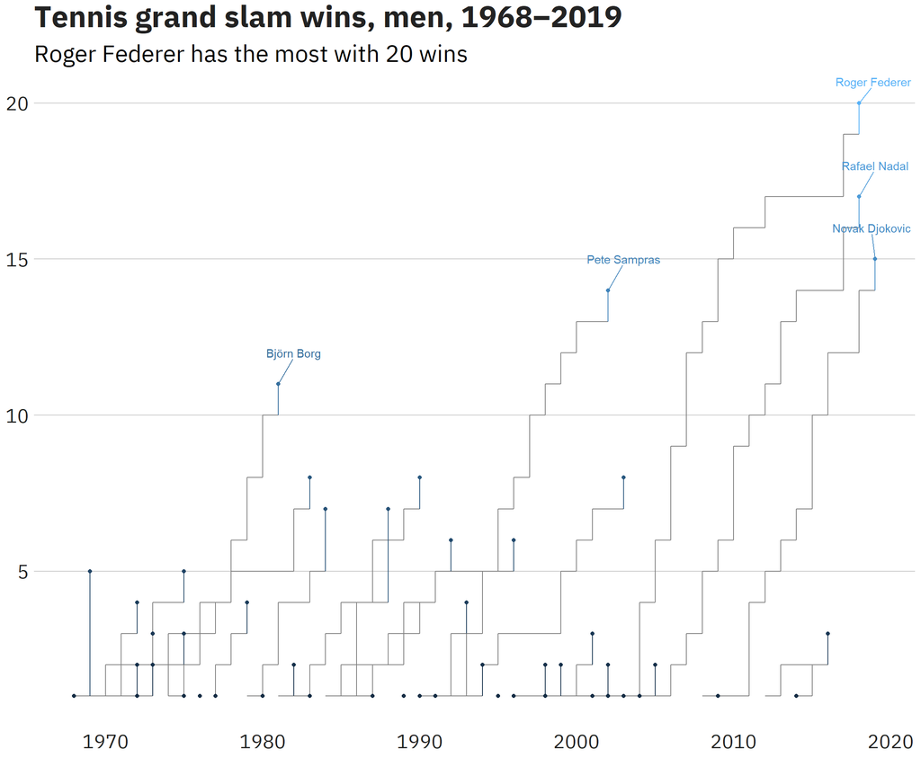

```r
men_gs <-
  grand_slams %>% filter(gender == "Male") %>% group_by(name) %>% distinct(year, tournament_date, .keep_all = TRUE) %>% mutate(rolling_win_count2 = row_number()) %>%  mutate(total_wins = if_else(year != max(year), NA_integer_, max(rolling_win_count2))) %>%  mutate(label = if_else(year == max(year), as.character(name), NA_character_))

  men <- ggplot(men_gs,
  aes(year, rolling_win_count2, label = name, colour = total_wins)) +
  geom_step(data = men_gs,
  mapping = aes(x = year, y = rolling_win_count2, group = name)) +
  geom_text_repel(
  aes(label = label),
  data  = subset(men_gs, rolling_win_count2 > 10),
  nudge_x = 1, nudge_y = 1,
  na.rm = TRUE
  ) + labs(
  x = "Year",
  y = "Number of wins",
  title = "Tennis grand slam wins, men, 1968\u20132019",
  subtitle = "Roger Federer has the most with 20 wins"
  ) + style() + geom_point(aes(x = year, y = total_wins))
men
```

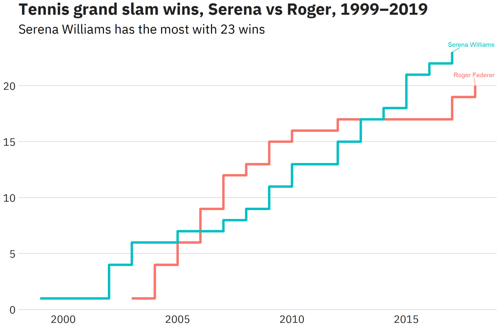

```r
sr <-
  grand_slams %>% filter(name == "Serena Williams" | name == "Roger Federer") %>% group_by(name) %>% mutate(label = if_else(year == max(year), as.character(name), NA_character_))

plot <- ggplot(sr,
  aes(year, rolling_win_count, label = name, colour = name)) +
  geom_step(data = sr,
  mapping = aes(x = year, y = rolling_win_count, group = name), size=2) +
  geom_text_repel(
  aes(label = label),
  nudge_x = 1, nudge_y = 1,
  na.rm = TRUE
  ) + labs(
  x = "Year",
  y = "Number of wins",
  title = "Tennis grand slam wins, Serena vs Roger, 1999\u20132019",
  subtitle = "Serena Williams has the most with 23 wins"
  ) + style()
plot
```

Lets animate the race between Serena Williams and Roger Federer over time

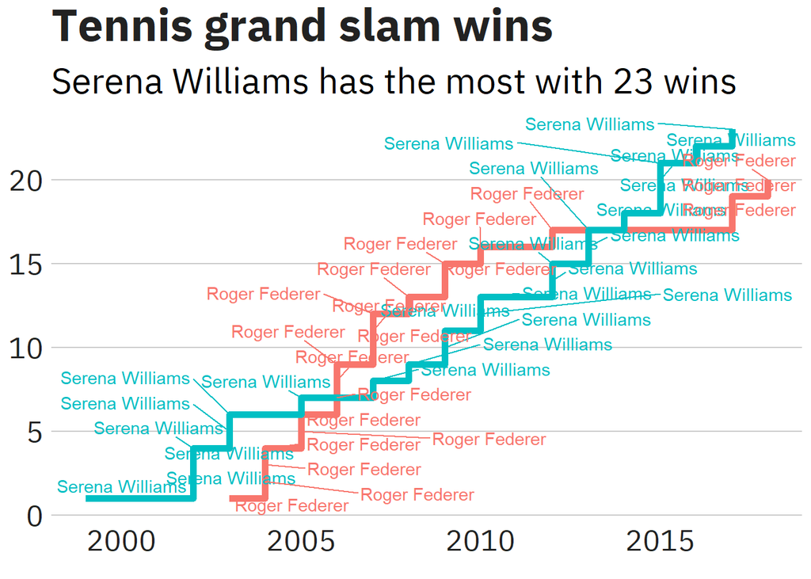

```r
library(gganimate)
library(gifski)
#The chart has to modified slightly to work as an animated GIF
plot2 <- ggplot(sr,
  aes(year, rolling_win_count, label = name, colour = name)) +
  geom_step(data = sr,
  mapping = aes(x = year, y = rolling_win_count, group = name), size=2) +
  geom_text_repel(
  aes(label = name),
  nudge_x = 1, nudge_y = 1,
  na.rm = TRUE
  ) + labs(
  title = "Tennis grand slam wins",
  subtitle = "Serena Williams has the most with 23 wins"
  ) + style()
plot2
```

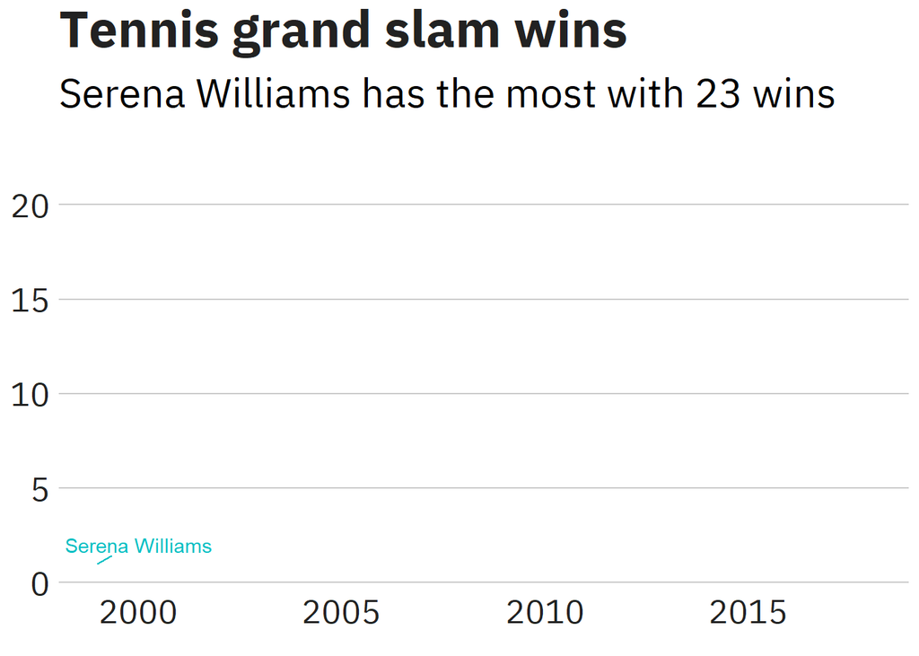

```r
anim <- plot2 + transition_reveal(year)
anim
```

```r
#Save the animated chart as a GIF
anim_save("serena_roger_slams.gif")
```

## Results

```r
ggsave("women_grand_slams.png", plot = women, width = 10, height = 8)
ggsave("men_grand_slams.png", plot = men, width = 10, height = 8)
ggsave("serena_roger.png", plot = plot, width = 12, height = 8)
```

Save the fixed data set with duplicates removed and the rolling_win_count variable fixed (use rolling_win_count2 for analysis/visualisation).

```r
grand_slams_fix <-  grand_slams %>% group_by(name) %>% distinct(year, tournament_date, .keep_all = TRUE) %>% mutate(rolling_win_count2 = row_number()) %>%  mutate(total_wins = if_else(year != max(year), NA_integer_, max(rolling_win_count2))) %>%  mutate(label = if_else(year == max(year), as.character(name), NA_character_))


#Output the tidy dataset for future use.
write.csv(grand_slams_fix, file = "grand_slams_fix.csv")
```

## Discussion/conclusions

- Step charts are fairly easy to generate using ggplot2 and geom_step
- The bbc style gives the charts a nice clean look to them
- ggrepel was fairly easy to use to label the lines
- The most challenging part was working out how to put the point on the end of the line
- It was relatively easy to animate the step chart showing the wins over time for Serena Williams and Roger Federer

## Package citations

Hadley Wickham (2017). tidyverse: Easily Install and Load the ‘Tidyverse’. R package version 1.2.1. https://CRAN.R-project.org/package=tidyverse

Kamil Slowikowski (2018). ggrepel: Automatically Position Non-Overlapping Text Labels with ‘ggplot2’. R package version 0.8.0. https://CRAN.R-project.org/package=ggrepel

Thomas Lin Pedersen and David Robinson (2019). gganimate: A Grammar of Animated Graphics. R package version 1.0.3. https://CRAN.R-project.org/package=gganimate